# M4_design_effective_visualizations

YG

2023-02-03

#Tips for effective visulization 1. keep it simple 2. use color to draw attention 3. tell a story

#Principles for effective visulization 1. order matters 2. put long categories on the y-axis 3. keep scales consistent 4. select meaningful colors 5. use meaningful and nonredundant labels

```r
library(tidyverse)
bx <- read_csv("brexit.csv")
```

1. order matters

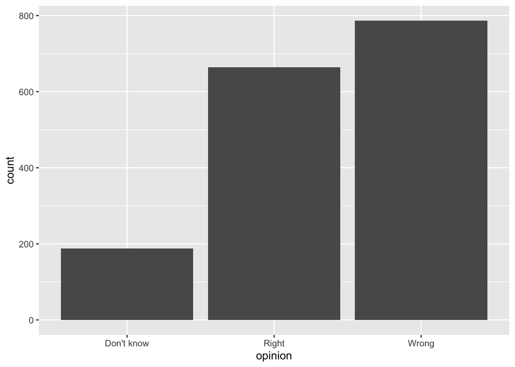

```r
ggplot(bx, aes(x = opinion)) +
  geom_bar()
```

fct_infreq():reorder factors’ levels by frequency

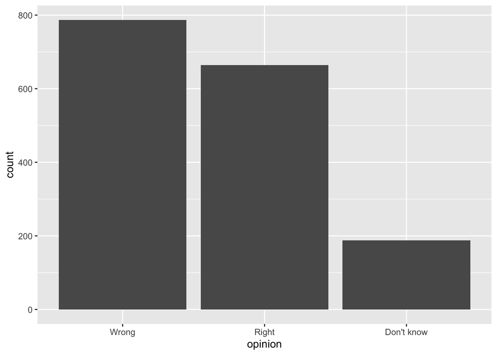

```r
ggplot(bx, aes(x=fct_infreq(opinion))) +
  geom_bar() +
  labs(
    x="opinion",
    y="count"
  ) #clean up labels
```

alphabetical order is rarely ideal

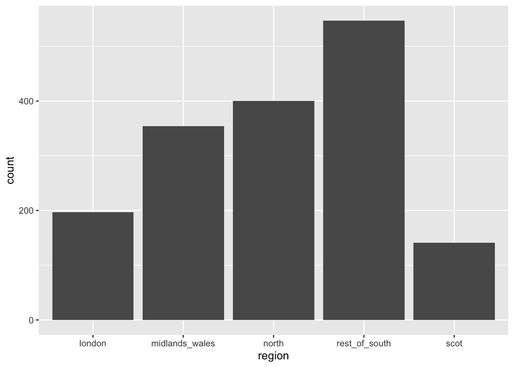

```r
ggplot(bx, aes(x=region)) +
  geom_bar()
```

fct_relevel:reorder factor levels using a custom order

```r
bx <- bx %>%
  mutate(
    region = fct_relevel(
      region,
      "london", "rest_of_south", "midlands_wales", "north", "scot"
    )
  )
```

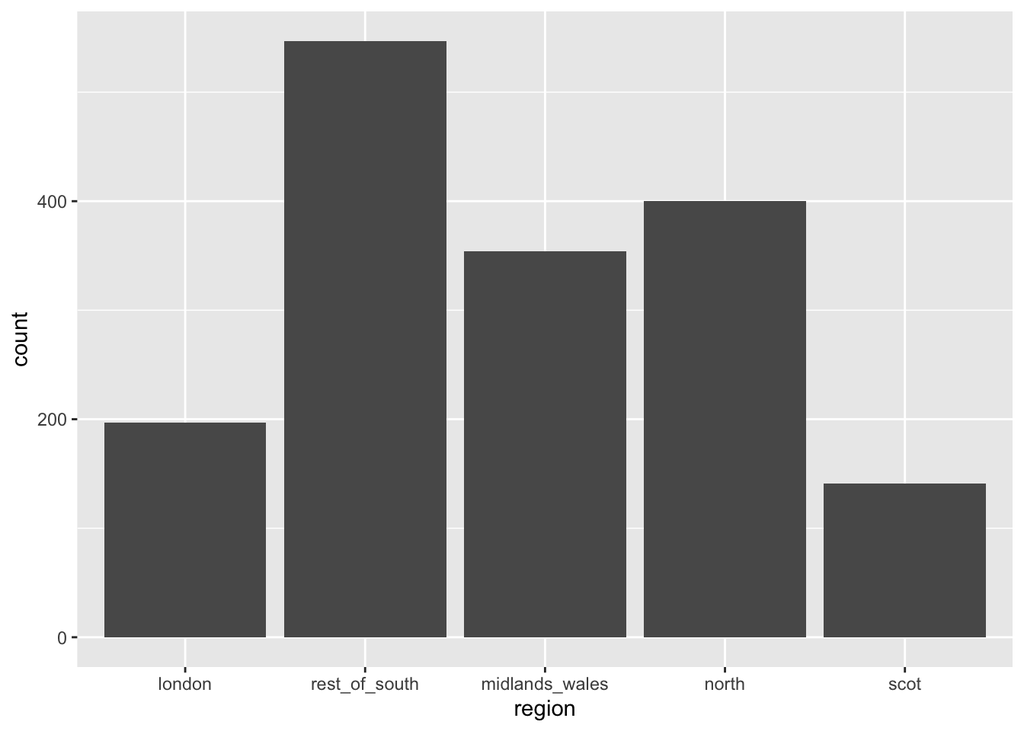

```r
ggplot(bx, aes(x=region)) +
  geom_bar()
```

fct_recode:change factor level names by hand

```r
bx <- bx %>%
  mutate(
    region = fct_recode(
      region,
      'London' = "london",
      'Rest of South' = "rest_of_south",
      'Midlands / Wales' = "midlands_wales",
      'North' = "north",
      'Scotland' = "scot"
    )
  )
```

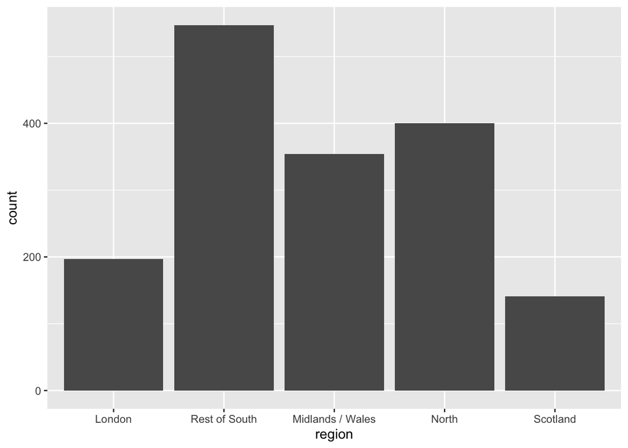

```r
ggplot(bx, aes(x=region)) +
  geom_bar()
```

2. put long categories on the y-axis

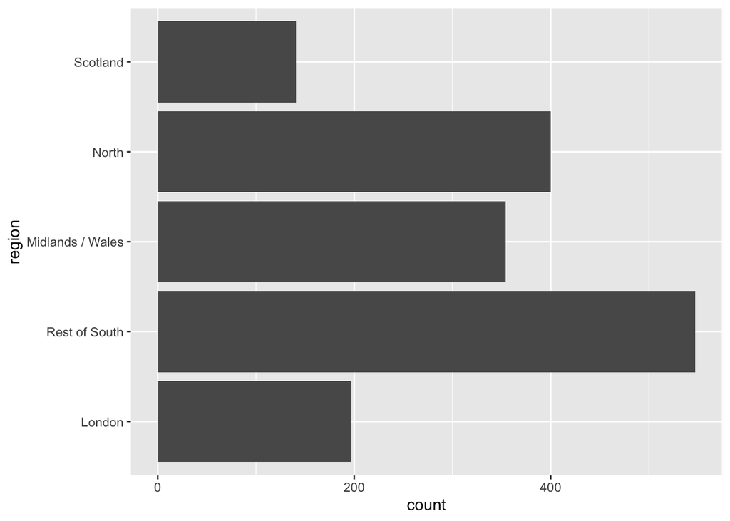

```r
ggplot(bx, aes(x=region)) +
  geom_bar() +
  coord_flip()
```

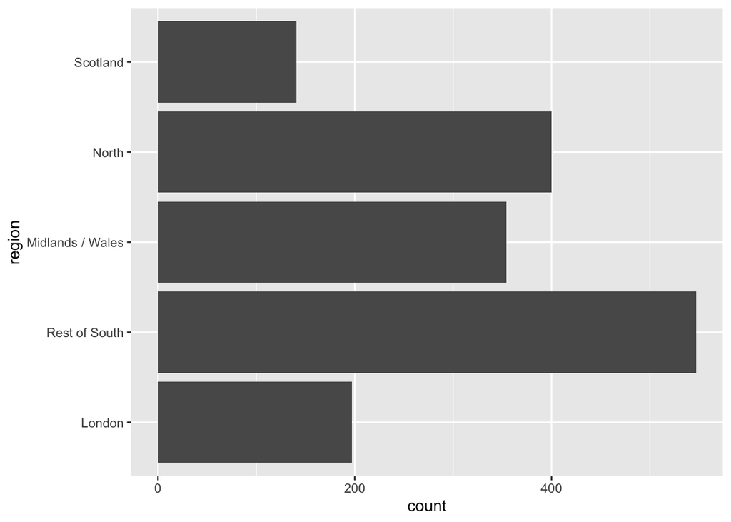

```r
ggplot(bx, aes(y=region)) +
  geom_bar()
```

fct_rev:reverse order of factor levels

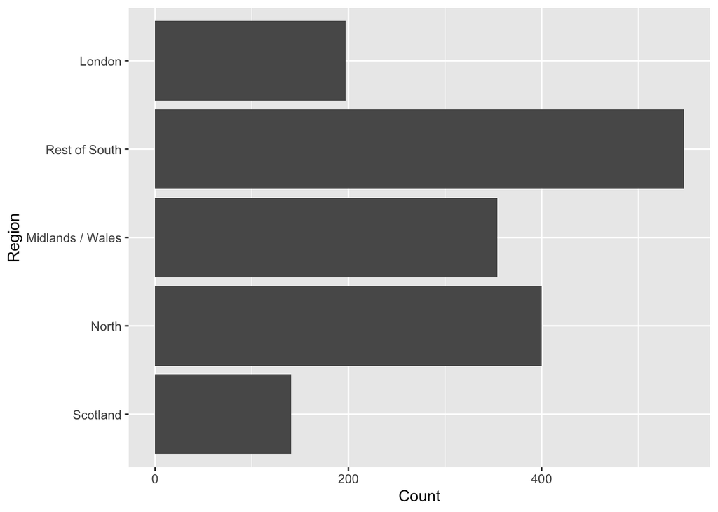

```r
ggplot(bx, aes(y=fct_rev(region))) +
  geom_bar() +
  labs(x = "Count",
       y = "Region")
```

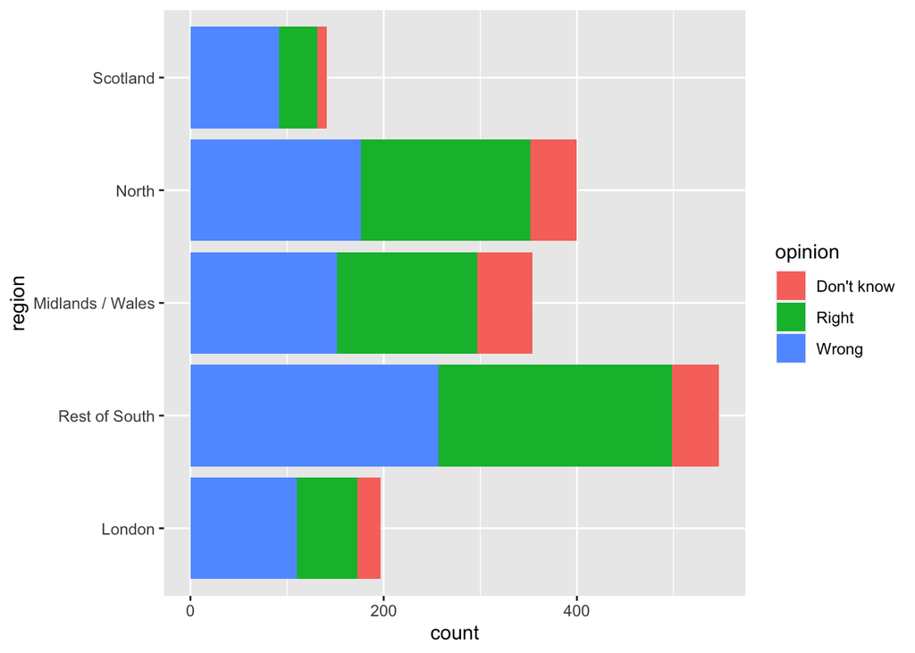

```r
ggplot(bx, aes(y=region, fill=opinion)) +
  geom_bar()
```

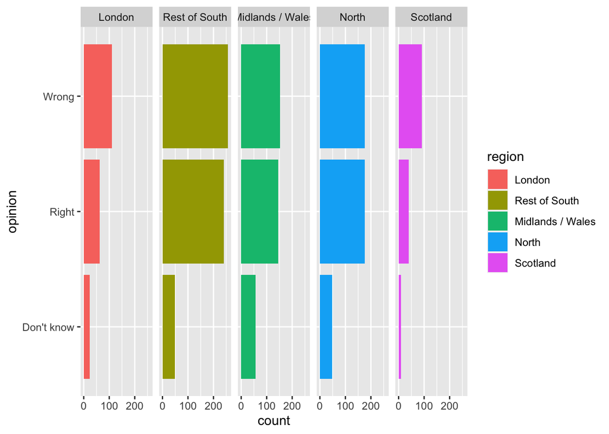

```r
ggplot(bx, aes(y=opinion, fill=region)) +
  geom_bar() +
  facet_wrap(~region, nrow = 1)
```

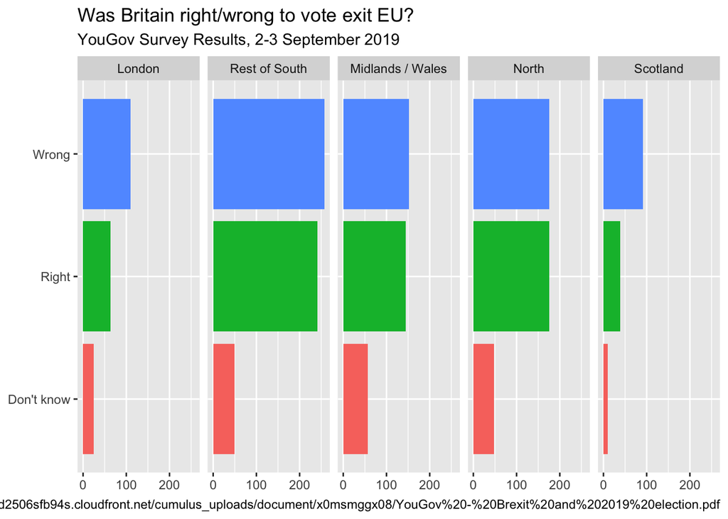

```r
ggplot(bx, aes(y=opinion, fill=opinion)) +
  geom_bar() +
  facet_wrap(~region, nrow = 1) +
  guides(fill=FALSE) +
  labs(
    title = "Was Britain right/wrong to vote exit EU?",
    subtitle = "YouGov Survey Results, 2-3 September 2019",
    caption = "Source:https://d25d2506sfb94s.cloudfront.net/cumulus_uploads/document/x0msmggx08/YouGov%20-%20Brexit%20and%202019%20election.pdf",
    x = NULL,
    y = NULL
  )
```

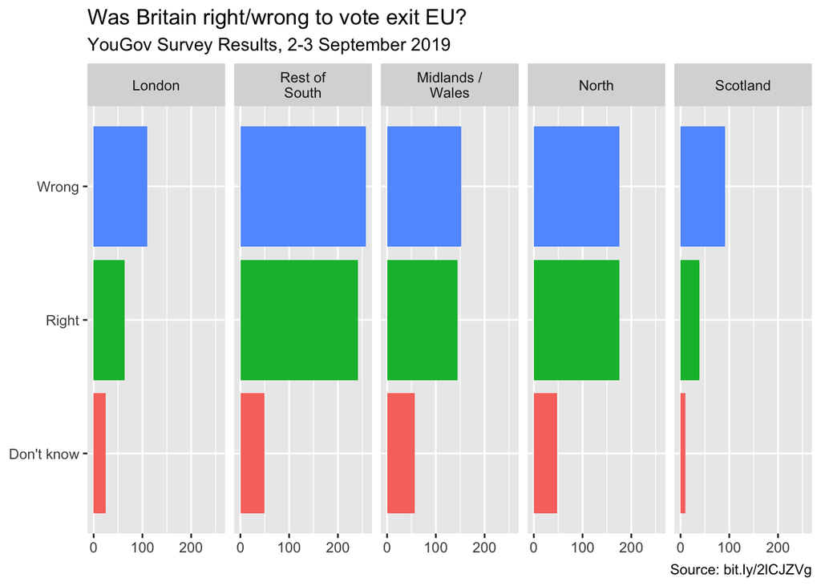

```r
ggplot(bx, aes(y=opinion, fill=opinion)) +
  geom_bar() +
  facet_wrap(~region, nrow = 1) +
  facet_wrap(~region,
             nrow = 1,
             labeller = label_wrap_gen(width = 12)) +
  guides(fill=FALSE) +
  labs(
    title = "Was Britain right/wrong to vote exit EU?",
    subtitle = "YouGov Survey Results, 2-3 September 2019",
    caption = "Source: bit.ly/2lCJZVg",
    x = NULL,
    y = NULL
  )
```

4. select meaningful colors

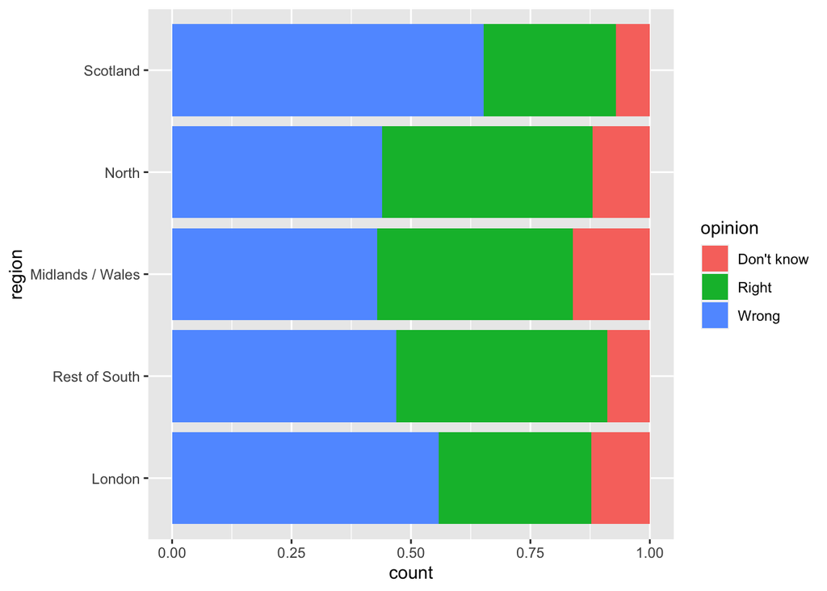

```r
ggplot(bx, aes(y=region, fill=opinion)) +
  geom_bar(position="fill")
```

Choose color manually

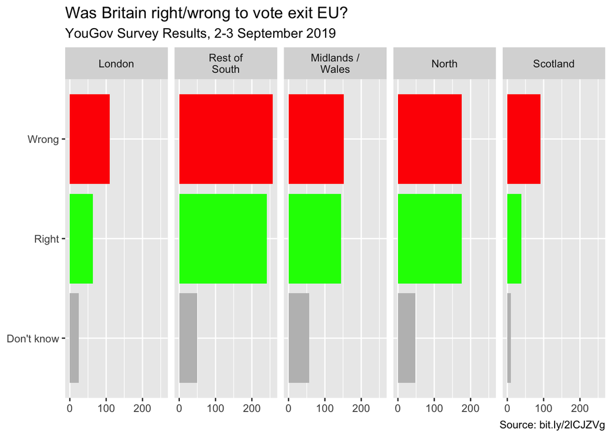

```r
ggplot(bx, aes(y=opinion, fill=opinion)) +
  geom_bar() +
  facet_wrap(~region, nrow = 1) +
  facet_wrap(~region,
             nrow = 1,
             labeller = label_wrap_gen(width = 12)) +
  guides(fill=FALSE) +
  labs(
    title = "Was Britain right/wrong to vote exit EU?",
    subtitle = "YouGov Survey Results, 2-3 September 2019",
    caption = "Source: bit.ly/2lCJZVg",
    x = NULL,
    y = NULL
  ) +
  scale_fill_manual(values = c(
    "Wrong" = "red",
    "Right" = "green",
    "Don't know" = "grey"
  ))
```

colorbrewer2

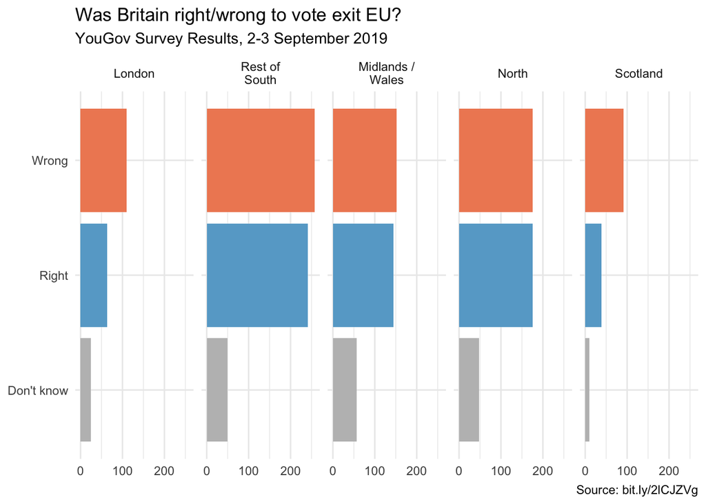

```r
ggplot(bx, aes(y=opinion, fill=opinion)) +
  geom_bar() +
  facet_wrap(~region, nrow = 1) +
  facet_wrap(~region,
             nrow = 1,
             labeller = label_wrap_gen(width = 12)) +
  guides(fill=FALSE) +
  labs(
    title = "Was Britain right/wrong to vote exit EU?",
    subtitle = "YouGov Survey Results, 2-3 September 2019",
    caption = "Source: bit.ly/2lCJZVg",
    x = NULL,
    y = NULL
  ) +
  scale_fill_manual(values = c(
    "Wrong" = "#ef8a62",
    "Right" = "#67a9cf",
    "Don't know" = "gray"
  )) +
  theme_minimal()
```

Viridis scale works well with ordinal data

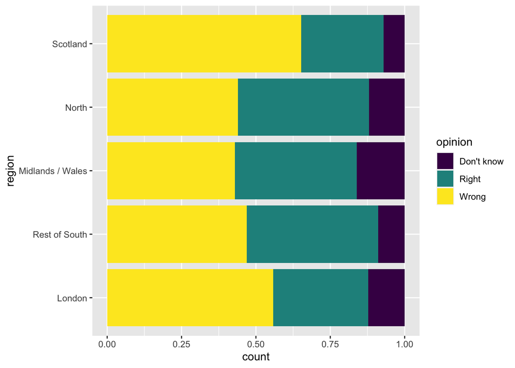

```r
ggplot(bx, aes(y=region, fill=opinion)) +
  geom_bar(position = "fill") +
  scale_fill_viridis_d()
```

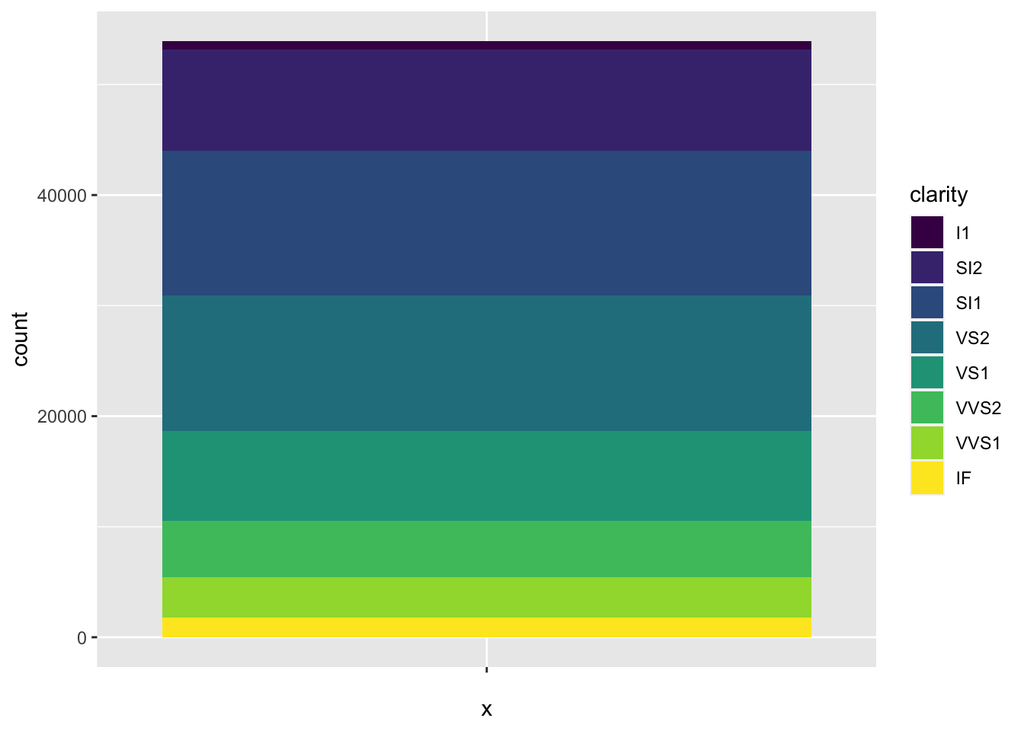

```r
barplot <- ggplot(diamonds, aes(x="", fill=clarity)) +
  geom_bar(width = 1, position = "stack")
barplot
```

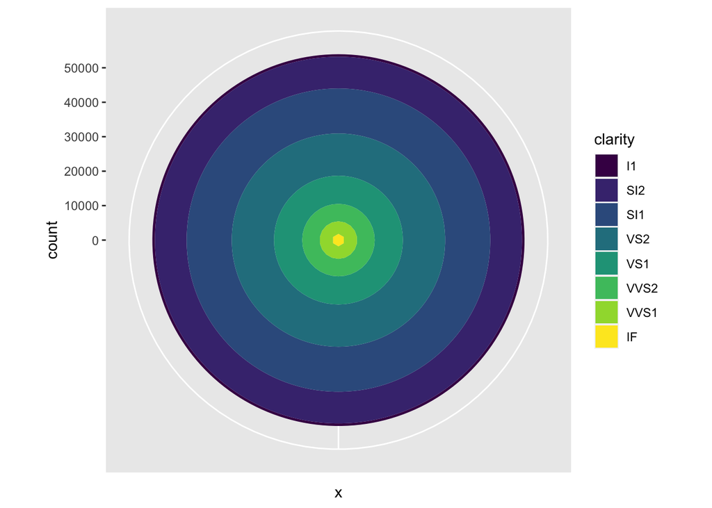

```r
barplot + coord_polar()
```

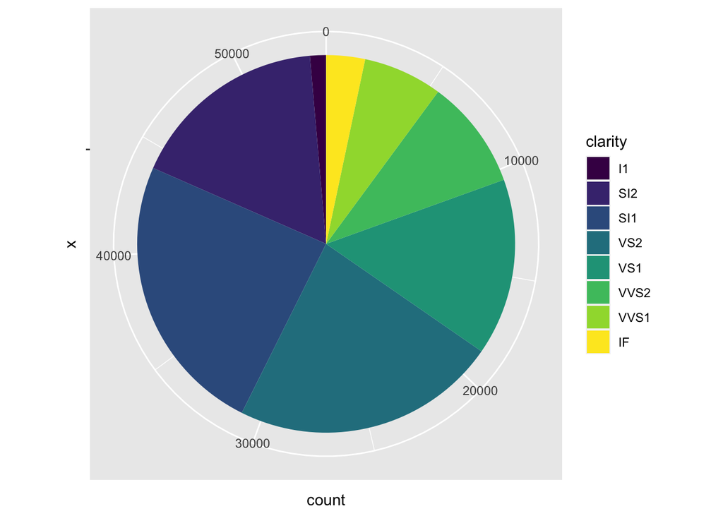

```r
barplot + coord_polar(theta = "y")
```

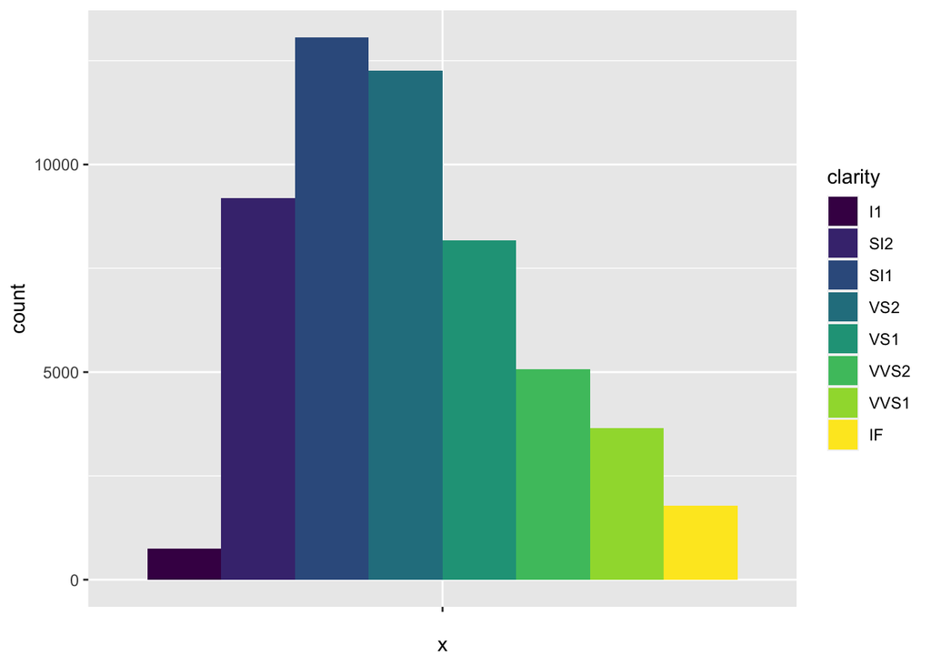

```r
barplot <- ggplot(diamonds, aes(x="", fill=clarity)) +
  geom_bar(width = 1, position = "dodge")
barplot
```

Components of a plot 1. a default data set and set of mappings from variables to aesthetics 2. one or more layers -one geommetric object (geom_) -one statistical transformation (stat_) -one position adjustment(position_) 3. one dataset and set of aesthetic mappings 4. a coordinate system(coord_*) 5. a facet sepecification(facet_*)

```r
md <- read_csv("minard.csv")
md_city <- read_csv("minard-cities.csv")
md_temp <- read_csv("minard-temps.csv")
```

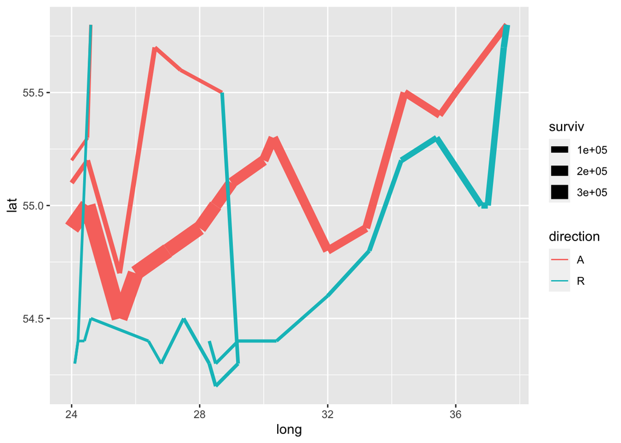

```r
plot_troops <- ggplot(md) +
  geom_path(aes(x=long,
                y=lat,
                color=direction,
                linewidth=surviv,
                group=division))
plot_troops
```

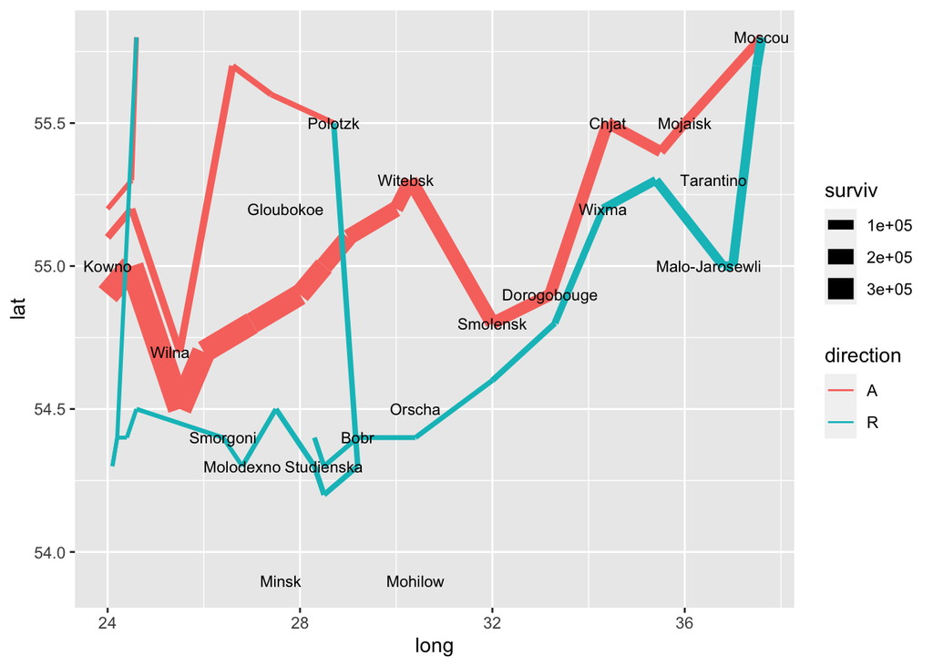

```r
plot_both <- plot_troops +
  geom_text(data=md_city,
            aes(x=long,
                y=lat,
                label=city),
            size=3)
plot_both
```

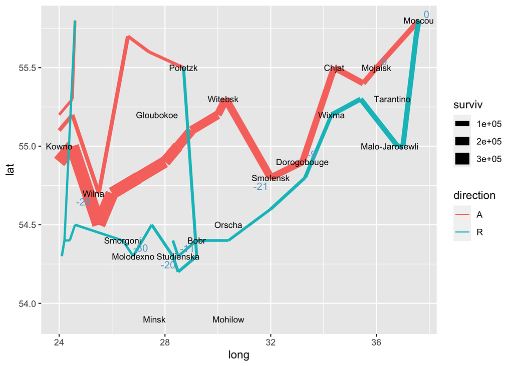

```r
library(ggrepel)
plot_all <- plot_both +
  geom_text_repel(data = md_temp,
            aes(x=long,
                y=lat,
                label=temp),
            size=3.5,
            color="#67a9cf"
            )
plot_all
```

[figure not shown]

```r
ggplot(md) +
  geom_path(aes(x = long,
                y = lat,
                color = direction,
                size = surviv^2,
                group = division),
            lineend = "round") +
  geom_text(aes(x = long,
                y = lat,
                label = city),
            data = md_city,
            size = 3) +
  geom_text_repel(aes(x = long,
                      y = lat,
                      label = temp),
                  data = md_temp,
                  size = 3,
                  color="#67a9cf"
                  ) +
  scale_size(range = c(.18,15),
             breaks = (1:3*10^5)^2,
             labels =
               scales :: comma(1:3*10^5),
             "Survivors") +
  scale_color_manual(values = c("grey50",
                                  "red"),
                       breaks = c("A",
                                  "R"),
                       labels = c("Advance",
                                  "Retreat"),
                       "") +
    xlab(NULL) + ylab(NULL) +
    theme(axis.text = element_blank(),
          axis.ticks = element_blank(),
          panel.grid = element_blank())
```